# Markdown file to accompany PDA submission on maxent.ot

anonymous

2023-04-19

This is a bare-bones R Markdown file to accompany a 2023 PDA submission on maxent.ot. Section headings and code chunks are identical to those in the submission, but with minimal surrounding text. Sections and sub-sections of the submission that have no R code are left blank here, with only the headings to help with navigation.

To view, use, and alter the .Rmd file, open it in RStudio, and then…

- To run all the code, click the **Knit** button, which will generate an html file containing the content and the output of the R code chunks
- To run individual parts of the code…
  - first, from the Session menu in RStudio, select Session > Set Working Directory > To Source File Location
  - run a whole code chunk by placing the cursor anywhere in the chunk and typing CTRL+SHIFT+ENTER
  - run a single line of code by placing the cursor anywhere in the line of code and typing CTRL+ENTER

First, set random seed, to ensure consistency of results

```r
set.seed(321)
```

# 1 Introduction: Why this package

## 1.1 The problem of switching out of an analysis script

## 1.2 Goals of this software

## 1.3 Overview

# 2 Reproducible research

## 2.1 R Markdown for reproducible research

## 2.2 Benefits of reproducible research

# 3 Carrying out a MaxEnt analysis using maxent.ot

## 3.1 Installing the package

Install and load the package.

```r
# Commenting this out for anonymity in submission. Please install maxent.ot
# using the isntructions in READ_THIS_FIRST.txt.

#install.packages("maxent.ot")

# if (!require(devtools)) {
#   install.packages("devtools", repos = "http://cran.us.r-project.org")
# }

# #This if-then statement will install the maxent.ot package only if it's not already installed. If you have the package installed but want to re-install the latest version, comment out (put "#" before) the if-then statement, and uncomment the next line instead:
# if (!require(maxent.ot)) {
#   devtools::install_github("REDACTED")
# }
#
# # Uncomment this line (delete the "#") if you want to install the package afresh, even if you already have (a version of) it installed:
# # devtools::install_github("REDACTED")

# Load the library
library(maxent.ot)
```

## 3.2 A running example: simplification of onset clusters by French-acquiring children

## 3.3 Formatting data for maxent.ot

Read in toy data

```r
if (!require(tidyverse)) {
  install.packages("tidyverse", repos = "http://cran.us.r-project.org")
}
library(tidyverse)

simple_input <- read_csv("data/simple_input_dataframe.csv")
```

## 3.4 MaxEnt background: Constraint grammars

## 3.5 MaxEnt background: How MaxEnt relates harmony to probability

## 3.6 MaxEnt background: Conditional log likelihood, a metric to quantify how well a model fits the data

## 3.7 Calculating candidate distributions and conditional likelihoods

Use predict_probabilities

```r
result <- predict_probabilities(simple_input, c(2,1))

result$loglik
```

```
## [1] -265.3047
```

```r
# -265.3047

result$predictions
```

```
##     Input  Output Freq StarComplex Max Predicted Observed       Error
## 1    stad    stad   40           1   0 0.2689414      0.4 -0.13105858
## 2    stad     tad   60           0   1 0.7310586      0.6  0.13105858
## 3    grav    grav   60           1   0 0.2689414      0.6 -0.33105858
## 4    grav     gav   40           0   1 0.7310586      0.4  0.33105858
## 5 spagEti spagEti   10           1   0 0.2689414      0.1  0.16894142
## 6 spagEti  pagEti   90           0   1 0.7310586      0.9 -0.16894142
## 7   gryjo   gryjo   30           1   0 0.2689414      0.3 -0.03105858
## 8   gryjo    gyjo   70           0   1 0.7310586      0.7  0.03105858
```

## 3.8 Learning weights in a MaxEnt grammar

Use optimize_weights

```r
simple_model <- optimize_weights(simple_input)

simple_model$weights
```

```
## StarComplex         Max
##   0.6190392   0.0000000
```

```r
# StarComplex Max
# 0.6190392 0.0000000

simple_model$loglik
```

```
## [1] -258.9787
```

```r
# -258.9787

simple_model$k
```

```
## [1] 2
```

```r
# 2

simple_model$n
```

```
## [1] 400
```

```r
# 400

simple_model$bias_params
```

```
## [1] NA
```

```r
# NA
```

Get probabilities

```r
result <- predict_probabilities(simple_input, simple_model$weights)

result$loglik
```

```
## [1] -258.9787
```

```r
# -258.9787

result$predictions
```

```
##     Input  Output Freq StarComplex Max Predicted Observed       Error
## 1    stad    stad   40           1   0      0.35      0.4 -0.05000001
## 2    stad     tad   60           0   1      0.65      0.6  0.05000001
## 3    grav    grav   60           1   0      0.35      0.6 -0.25000001
## 4    grav     gav   40           0   1      0.65      0.4  0.25000001
## 5 spagEti spagEti   10           1   0      0.35      0.1  0.24999999
## 6 spagEti  pagEti   90           0   1      0.65      0.9 -0.24999999
## 7   gryjo   gryjo   30           1   0      0.35      0.3  0.04999999
## 8   gryjo    gyjo   70           0   1      0.65      0.7 -0.04999999
```

### 3.8.1 Test against new data

Test grammar against new data

```r
wug_input <- read_csv("data/simple_wug.csv")
result_wug <- predict_probabilities(wug_input, simple_model$weights)

result_wug$loglik
```

```
## [1] -5.491637
```

```r
# -5.491637

result_wug$predictions
```

```
##   Input Output Freq StarComplex Max Predicted  Observed      Error
## 1 ?k?ob  ?k?ob    4           1   0      0.35 0.5714286 -0.2214286
## 2 ?k?ob   ?kob    3           0   1      0.65 0.4285714  0.2214286
```

## 3.9 Compare how well different models fit the data

Full model

```r
# copy the original data and add new constraint violations
max_stressed_ssp_input <- simple_input %>%
  mutate(MaxStressed = c(0,1,0,1,0,0,0,0),
         SSP = c(1,0,0,0,1,0,0,0))

# Remove SSP column for model without SSP
max_stressed_input <- max_stressed_ssp_input %>%
  select(-SSP)

# Remove MaxStressed column for model without MaxStressed
ssp_input <- max_stressed_ssp_input %>%
  select(-MaxStressed)
```

Fit weights to new scenarios

```r
model_max_stressed <- optimize_weights(max_stressed_input)
model_ssp <- optimize_weights(ssp_input)
model_max_stressed_ssp <- optimize_weights(max_stressed_ssp_input)
```

Get each model’s predictions

```r
# Apply predict_probability to each model
result_basic <- predict_probabilities(simple_input, simple_model$weights)

result_max_stressed <- predict_probabilities(
  max_stressed_input, model_max_stressed$weights
)

result_ssp <- predict_probabilities(ssp_input, model_ssp$weights)

result_max_stressed_ssp <- predict_probabilities(
  max_stressed_ssp_input, model_max_stressed_ssp$weights
)

# Consolidate model predictions into single tibble
# Round and format for readability
results_compiled <- result_max_stressed_ssp$predictions %>%
  select(-Error, -Predicted) %>%
  mutate(`Pred. basic` = result_basic$predictions$Predicted,
         `Pred. w/ MaxStr` = result_max_stressed$predictions$Predicted,
         `Pred. w/ SSP` = result_ssp$predictions$Predicted,
         `Pred. w/ both` = result_max_stressed_ssp$predictions$Predicted) %>%
  mutate_at(vars(starts_with("Pred")), list(~ round(., 2)))

results_compiled
```

```
##     Input  Output Freq StarComplex Max MaxStressed SSP Observed Pred. basic
## 1    stad    stad   40           1   0           0   1      0.4        0.35
## 2    stad     tad   60           0   1           1   0      0.6        0.65
## 3    grav    grav   60           1   0           0   0      0.6        0.35
## 4    grav     gav   40           0   1           1   0      0.4        0.65
## 5 spagEti spagEti   10           1   0           0   1      0.1        0.35
## 6 spagEti  pagEti   90           0   1           0   0      0.9        0.65
## 7   gryjo   gryjo   30           1   0           0   0      0.3        0.35
## 8   gryjo    gyjo   70           0   1           0   0      0.7        0.65
##   Pred. w/ MaxStr Pred. w/ SSP Pred. w/ both
## 1             0.5         0.25          0.38
## 2             0.5         0.75          0.62
## 3             0.5         0.45          0.62
## 4             0.5         0.55          0.38
## 5             0.2         0.25          0.12
## 6             0.8         0.75          0.88
## 7             0.2         0.45          0.28
## 8             0.8         0.55          0.72
```

### 3.9.1 BIC

Make BIC by hand

```r
-2 * simple_model$loglik + simple_model$k * log(simple_model$n)
```

```
## [1] 529.9402
```

```r
# 529.9402
```

Use compare_models to get BIC

```r
options(scipen = 999)
options(digits = 5)
compare_models(
  simple_model, model_max_stressed, model_ssp, model_max_stressed_ssp,
  method = "bic"
)
```

```
##                    model k   n    bic bic.delta            bic.wt cum.wt
## 1 max_stressed_ssp_input 4 400 481.59     0.000 0.998996393522926  0.999
## 2     max_stressed_input 3 400 495.39    13.806 0.001003595038440  1.000
## 3              ssp_input 3 400 518.16    36.576 0.000000011407013  1.000
## 4           simple_input 2 400 529.94    48.352 0.000000000031622  1.000
##        ll
## 1 -228.81
## 2 -238.71
## 3 -250.09
## 4 -258.98
```

```r
options(digits = 7)
```

Model with an extra constraint

```r
# Make the new data tableau
# Copy the four-constraint data
# Add DoTheRightThing column
dtrt_input <- max_stressed_ssp_input %>%
  mutate(DoTheRightThing = c(0,1,1,0,1,0,0,1))

# Fit constraint weights
model_dtrt <- optimize_weights(dtrt_input)

# Retrieve model predictions
result_dtrt <- predict_probabilities(dtrt_input, model_dtrt$weights)

# Get log likelihood
result_dtrt$loglik
```

```
## [1] -228.1971
```

```r
# -228.1971
```

Ceiling log likelihood

```r
sum(simple_input$Frequency * log(simple_input$Frequency/100))
```

```
## [1] -228.1971
```

```r
#-228.1971
```

Compare models

```r
options(digits = 5)
compare_models(model_max_stressed_ssp, model_dtrt, method = "bic")
```

```
##                    model k   n    bic bic.delta   bic.wt  cum.wt      ll
## 1 max_stressed_ssp_input 4 400 481.59    0.0000 0.915426 0.91543 -228.81
## 2             dtrt_input 5 400 486.35    4.7635 0.084574 1.00000 -228.20
```

### 3.9.2 AIC and AICc

Compare AICs

```r
compare_models(
  simple_model, model_max_stressed, model_ssp, model_max_stressed_ssp,
  model_dtrt, method = "aic"
)
```

```
##                    model k    aic aic.delta              aic.wt  cum.wt      ll
## 1 max_stressed_ssp_input 4 465.62   0.00000 0.59527945074509503 0.59528 -228.81
## 2             dtrt_input 5 466.39   0.77207 0.40463926902930786 0.99992 -228.20
## 3     max_stressed_input 3 483.42  17.79779 0.00008127930141631 1.00000 -238.71
## 4              ssp_input 3 506.19  40.56753 0.00000000092383280 1.00000 -250.09
## 5           simple_input 2 521.96  56.33526 0.00000000000034808 1.00000 -258.98
```

Compare AICcs

```r
compare_models(
  simple_model, model_max_stressed, model_ssp, model_max_stressed_ssp,
  model_dtrt, method = "aic_c"
)
```

```
##                    model k   n   aicc aicc.delta             aicc.wt  cum.wt
## 1 max_stressed_ssp_input 4 400 465.72    0.00000 0.60140768797465816 0.60141
## 2             dtrt_input 5 400 466.55    0.82309 0.39850850852858155 0.99992
## 3     max_stressed_input 3 400 483.48   17.75713 0.00008380254388359 1.00000
## 4              ssp_input 3 400 506.25   40.52687 0.00000000095251235 1.00000
## 5           simple_input 2 400 521.99   56.26422 0.00000000000036438 1.00000
##        ll
## 1 -228.81
## 2 -228.20
## 3 -238.71
## 4 -250.09
## 5 -258.98
```

### 3.9.3 Likelihood ratio test

Likelihood ratio

```r
compare_models(model_max_stressed_ssp, model_dtrt, method = "lrt")
```

```
##                         description chi_sq k_delta p_value
## 1 dtrt_input~max_stressed_ssp_input 1.2279       1 0.26781
```

```r
options(digits = 7)
```

## 3.10 Using prior terms to encode bias or over-fitting

### 3.10.1 MaxEnt background: The Gaussian prior

### 3.10.2 Prior terms in maxent.ot

Apply a basic Gaussian bias, same values for all constraints

```r
# all constraints have mu of 0, sigma of 1
model_max_stressed_ssp_bias1 <- optimize_weights(
  max_stressed_ssp_input, mu = 0, sigma = 1
)

rbind(
  unbiased_weights = model_max_stressed_ssp$weights,
  biased_weights = model_max_stressed_ssp_bias1$weights
)
```

```
##                  StarComplex        Max MaxStressed       SSP
## unbiased_weights   1.0377363 0.07827311    1.461826 1.0047257
## biased_weights     0.9033141 0.00000000    1.355061 0.9608867
```

Calculating log likelihood and prior

```r
#log likelihoods
model_max_stressed_ssp$loglik
```

```
## [1] -228.811
```

```r
# -228.811
model_max_stressed_ssp_bias1$loglik
```

```
## [1] -228.9289
```

```r
# -228.9289

#priors
sum(((model_max_stressed_ssp$weights - 0)^2)/(2* 1^2))
```

```
## [1] 2.114716
```

```r
# 2.114716
sum(((model_max_stressed_ssp_bias1$weights - 0)^2)/(2* 1^2))
```

```
## [1] 1.787735
```

```r
# 1.787735

#values of objective function
model_max_stressed_ssp$loglik - sum(((model_max_stressed_ssp$weights - 0)^2)/(2* 1^2))
```

```
## [1] -230.9257
```

```r
# -230.9257
model_max_stressed_ssp_bias1$loglik - sum(((model_max_stressed_ssp_bias1$weights - 0)^2)/(2* 1^2))
```

```
## [1] -230.7166
```

```r
# -230.7166
```

custom values for each constraint

```r
model_max_stressed_ssp_bias2 <- optimize_weights(
  max_stressed_ssp_input, mu = c(2,0,0,1), sigma = c(1, 1, 0.1, 1)
)

rbind(
  unbaised_weights = model_max_stressed_ssp$weights,
  biased_weights = model_max_stressed_ssp_bias1$weights,
  individually_biased_weights = model_max_stressed_ssp_bias2$weights
)
```

```
##                             StarComplex        Max MaxStressed       SSP
## unbaised_weights              1.0377363 0.07827311   1.4618256 1.0047257
## biased_weights                0.9033141 0.00000000   1.3550608 0.9608867
## individually_biased_weights   1.1705216 0.82951198   0.2499482 0.8893151
```

Read bias terms from a data frame or tibble.

```r
bias_table <- tibble(
  Constraint = c("StarComplex", "Max", "MaxStressed", "SSP"),
  Mu = c(2,0,0,1),
  Sigma = c(1, 1, 0.1, 1)
)

model_max_stressed_ssp_bias3 <- optimize_weights(
  max_stressed_ssp_input, bias_input = bias_table
)

model_max_stressed_ssp_bias3$weights
```

```
## StarComplex         Max MaxStressed         SSP
##   1.1705216   0.8295120   0.2499482   0.8893151
```

```r
# StarComplex Max MaxStressed SSP
# 1.1705216 0.8295120 0.2499482 0.8893151
```

# 4 Cross-validation

## 4.1 Example from the phonology of Shona

Read in Shona

```r
shona_input <- read_csv("data/Shona_tableaux.csv")
# display top left corner of tableaux
shona_input[1:10,1:10]
```

```
## # A tibble: 10 × 10
##    Input  Output  Frequency `Dep-i` `Dep-u` `Dep-e` `Dep-o` `Dep-a` `Dep-i/i`
##    <chr>  <chr>       <dbl>   <dbl>   <dbl>   <dbl>   <dbl>   <dbl>     <dbl>
##  1 tim    timi           31       1      NA      NA      NA      NA         1
##  2 tim    timu           11      NA       1      NA      NA      NA        NA
##  3 tim    time            0      NA      NA       1      NA      NA        NA
##  4 tim    timo            4      NA      NA      NA       1      NA        NA
##  5 tim    tima            4      NA      NA      NA      NA       1        NA
##  6 tSitof tSitofi        14       1      NA      NA      NA      NA        NA
##  7 tSitof tSitofu       106      NA       1      NA      NA      NA        NA
##  8 tSitof tSitofe         1      NA      NA       1      NA      NA        NA
##  9 tSitof tSitofo        13      NA      NA      NA       1      NA        NA
## 10 tSitof tSitofa         8      NA      NA      NA      NA       1        NA
## # ℹ 1 more variable: `Dep-u/i` <dbl>
```

```r
# make a version with a column for total frequency of each tableau, using a loop
# (will be useful for plots below)
# This works because every tableau in this data set has a unique input
shona_input_with_total <- shona_input %>%
    group_by(Input) %>%
    mutate(tableau_freq = sum(Frequency))
```

## 4.2 Using cross-validation to explore different values of sigma

Make a close-fitting model, with very large sigma

```r
shona_1000 <- optimize_weights(
  shona_input, mu = 0, sigma = 1000, upper_bound = 10
)

shona_1000_predictions <- predict_probabilities(
  shona_input, constraint_weights = shona_1000$weights
)

shona_1000_predictions$loglik
```

```
## [1] -874.2246
```

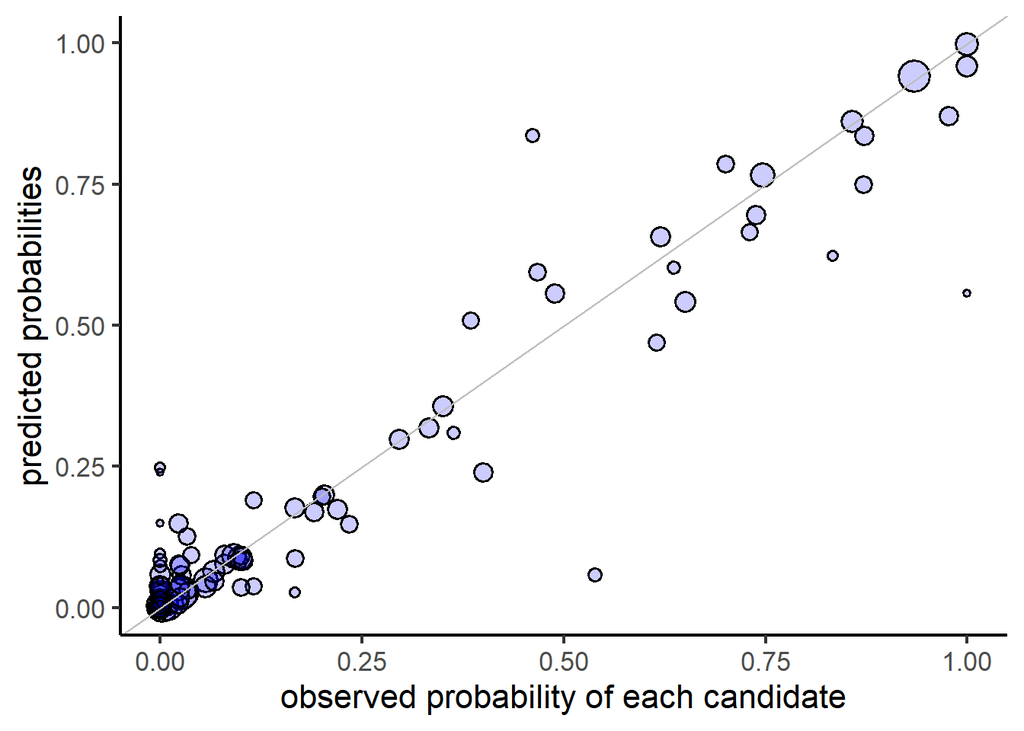

```r
# -874.2246

shona_1000_predictions$predictions %>%
  ggplot(aes(x=Observed, y=Predicted)) +
  geom_point(
    shape=21, fill=alpha("blue", 0.2), stroke=1,
    size=log(shona_input_with_total$tableau_freq)) +
  geom_abline(slope=1, intercept=0, color="grey") +
  xlab("observed probability of each candidate") +
  ylab("predicted probabilities") +
  theme_classic(base_size=16)
```

```r
ggsave('figures/Shona_1000.png', width=5, height=4, dpi=300)
```

Create partition

```r
# Housekeeping needed to format data the way partition_data() is expecting
# We're using internal functions from maxent.ot using the ::: operator
processed_input <- maxent.ot:::load_input(shona_input)
data <- processed_input$data

# slice data into 5 random parts
partitions <- maxent.ot:::partition_data(data, k=5)

# slice number 1 will be held out
hold_out <- 1

# the training slices
training_part <- partitions %>%
  filter(partition != hold_out)

# the held-out slice
test_part <- partitions %>%
  filter(partition == hold_out)

# housekeeping to set up data the way populate_tableau() expects
training_data <- data %>%
  mutate(Frequency = 0)
test_data <- training_data

# format the training and held-out data into tableaux
training_tableau <- maxent.ot:::populate_tableau(training_data, training_part)
test_tableau <- maxent.ot:::populate_tableau(test_data, test_part)
```

Fit to training slices only

```r
# Fit model to training data
shona_1000_crossval_model <- optimize_weights(
  training_tableau, mu = 0, sigma = 1000, control_params = NA, upper_bound = 10
)
shona_1000_crossval_model$loglik
```

```
## [1] -698.4757
```

```r
# Model's loglik = -698.4757
```

Get predictions of trained model

```r
# How does it do on the training data?
predictions_training <- predict_probabilities(
  training_tableau, shona_1000_crossval_model$weights
)

predictions_training$loglik / sum(predictions_training$predictions$Freq)
```

```
## [1] -0.5204737
```

```r
# average log likelihood: -0.5204737

# How does it do on the held-out data?
predictions_test <- predict_probabilities(
  test_tableau, shona_1000_crossval_model$weights
)

predictions_test$loglik / sum(predictions_test$predictions$Freq)
```

```
## [1] -0.5379555
```

```r
# average log likelihood: -0.5379555
```

Plot fits to training and held-out data (these code chunks were not included in the submission)

```r
# Give variables more-mnemonic names
shona_1000_crossval_fit_to_training <- predictions_training$predictions %>%
  mutate(type='training')
shona_1000_crossval_fit_to_test <- predictions_test$predictions %>%
  mutate(type='test')
shona_1000_crossval_fit <- rbind(
  shona_1000_crossval_fit_to_training, shona_1000_crossval_fit_to_test) %>%
  inner_join(shona_input_with_total %>%
               select(Input, Output, tableau_freq), by=c('Input', 'Output')) %>%
  mutate(type = fct_relevel(type, 'training'))
```

Code chunks omitted from submission: do cross-validation with two other values of sigma.

Try a too-strict sigma, 0.1

```r
#Fit model to training data
shona_point01_crossval_model <- optimize_weights(
  training_tableau, mu = 0, sigma = 0.1, upper_bound = 10
)

#How does it do on the training data?
shona_point01_crossval_fit_to_training <- predict_probabilities(
  test_input = training_tableau,
  constraint_weights = shona_point01_crossval_model$weights
)

shona_point01_crossval_fit_to_training$loglik / sum(training_tableau$Frequency)
```

```
## [1] -0.8339063
```

```r
# -0.8339063

# How does it do on the held-out data?
shona_point01_crossval_fit_to_test <- predict_probabilities(
  test_tableau, shona_point01_crossval_model$weights
)

shona_point01_crossval_fit_to_test$loglik / sum(test_tableau$Frequency)
```

```
## [1] -0.8290028
```

```r
# -0.8290028

shona_point01_crossval_fit_to_training <- shona_point01_crossval_fit_to_training$predictions %>%
  mutate(type='training')
shona_point01_crossval_fit_to_test <- shona_point01_crossval_fit_to_test$predictions %>%
  mutate(type='test')
shona_point01_crossval_fit <- rbind(
  shona_point01_crossval_fit_to_training, shona_point01_crossval_fit_to_test) %>%
  inner_join(shona_input_with_total %>%
               select(Input, Output, tableau_freq), by=c('Input', 'Output')) %>%
  mutate(type = fct_relevel(type, 'training'))
```

Try a moderate sigma, 3:

```r
#Fit model to training data
shona_3_crossval_model <- optimize_weights(
  training_tableau, mu = 0, sigma = 3, upper_bound = 10
)

#How does it do on the training data?
shona_3_crossval_fit_to_training <- predict_probabilities(
  test_input = training_tableau, constraint_weights = shona_3_crossval_model$weights
)

shona_3_crossval_fit_to_training$loglik / sum(training_tableau$Frequency)
```

```
## [1] -0.5242238
```

```r
# -0.5242238

#How does it do on the held-out data?
shona_3_crossval_fit_to_test <- predict_probabilities(
  test_input = test_tableau, constraint_weights = shona_3_crossval_model$weights
)

shona_3_crossval_fit_to_test$loglik / sum(test_tableau$Frequency)
```

```
## [1] -0.5317218
```

```r
# -0.5317218

shona_3_crossval_fit_to_training <- shona_3_crossval_fit_to_training$predictions %>%
  mutate(type='training')
shona_3_crossval_fit_to_test <- shona_3_crossval_fit_to_test$predictions %>%
  mutate(type='test')
shona_3_crossval_fit <- rbind(
  shona_3_crossval_fit_to_training, shona_3_crossval_fit_to_test) %>%
  inner_join(shona_input_with_total %>%
               select(Input, Output, tableau_freq), by=c('Input', 'Output')) %>%
  mutate(type = fct_relevel(type, 'training'))
```

Plot results.

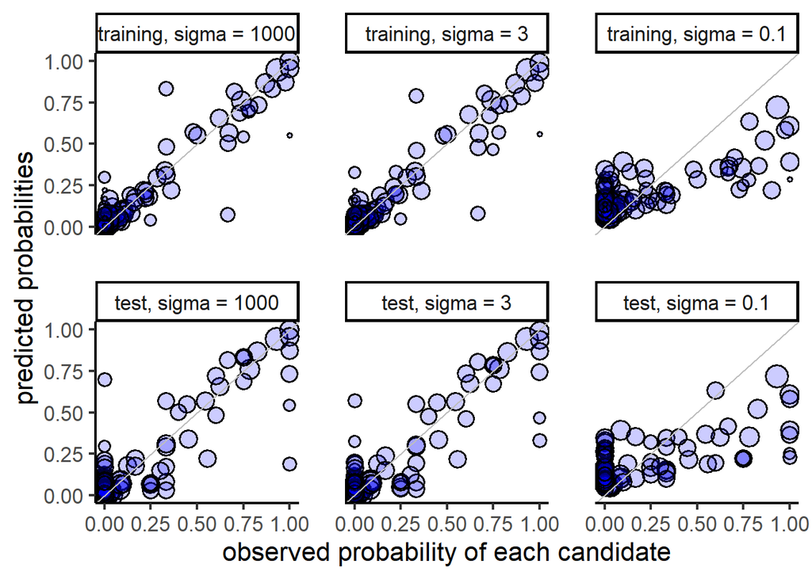

```r
shona_1000_crossval_fit$group <- 'sigma = 1000'
shona_point01_crossval_fit$group <- 'sigma = 0.1'
shona_3_crossval_fit$group <- 'sigma = 3'

shona_crossval_fit <- rbind(
  shona_1000_crossval_fit, shona_3_crossval_fit, shona_point01_crossval_fit
)

shona_crossval_fit <- shona_crossval_fit %>%
  mutate(group_type = str_c(type, group, sep=', '))

shona_crossval_fit <- shona_crossval_fit %>%
  mutate(group_type = fct_relevel(factor(
    group_type),
     c('training, sigma = 1000',
               'training, sigma = 3',
               'training, sigma = 0.1',
               'test, sigma = 1000',
               'test, sigma = 3',
               'test, sigma = 0.1')))

#Plot fit to training data
shona_crossval_fit %>%
  ggplot(aes(x=Observed, y=Predicted, size=log(tableau_freq))) +
  geom_point(
    shape=21, fill=alpha("blue", 0.2), stroke=1, show.legend = FALSE) +
  geom_abline(slope=1, intercept=0, color="grey") +
  xlab("observed probability of each candidate") +
  ylab("predicted probabilities") +
  theme_classic(base_size=16) +
  theme(panel.spacing = unit(2, "lines")) +
  facet_wrap(~ group_type, nrow=2)
```

```r
ggsave('figures/Shona_crossval.png', width=9, height=6, dpi=300)
```